# Introduction to Simulation Modeling

2022-07-18 08:56:24

## Introduction

- This lecture is a very short introduction to within-host modeling.
- More information and details are in the previously recorded lectures and the readings on the SMI website.
- Use Slack for any questions/thoughts/feedback (better than Zoom chat since it will stay).

## **Phenomenological/non-mechanistic/(statistical) models**

- Examples: t-test, linear/logistic regression model, deep neural network
- Always applied to data
- Are sometimes causal
- Do not describe mechanisms underlying the system of study

[figure not shown]

Source: xkcd.com

## Descriptive Analysis

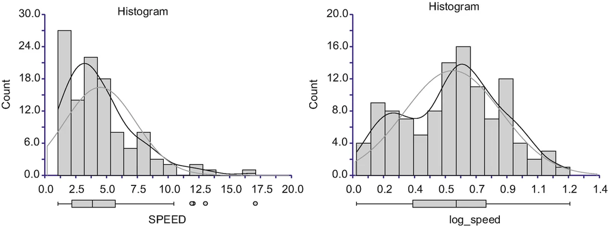

Source: Cooksey 2020 “Illustrating Statistical Procedures: Finding Meaning in Quantitative Data”

## Inference

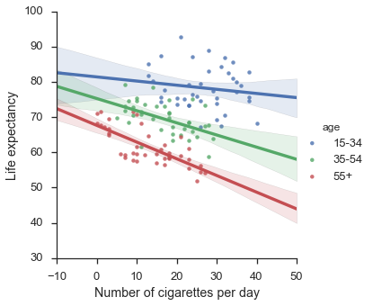

Not real data. See [here](http://ds.gregvi.al/2016/11/19/smoking-is-good/) for details.

## Prediction

[figure not shown]

## **Mechanistic/simulation models**

- Are always causal
- Include mechanisms
- Usually have a time/dynamic component
- Can be used with or without data

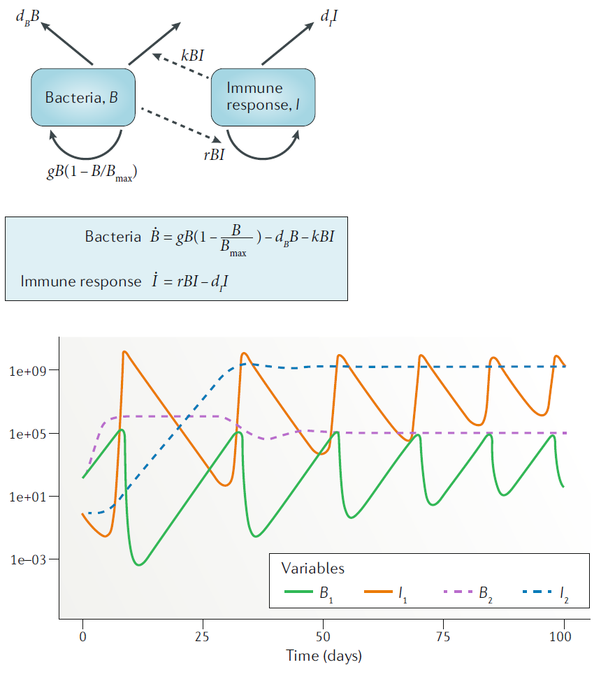

Source: *Simulation modelling for immunologists*

## Inference

\[ \begin{aligned} \dot U &= - b(1-e_1)UV\\ \dot I &= bUV - d_I I \\ \dot V &= p(1-e_2)I - d_V V - g b(1-e_1) UV \\ \end{aligned} \]

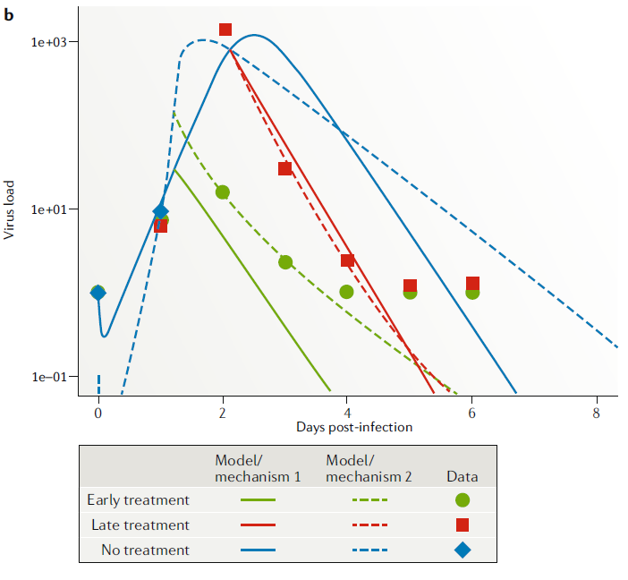

Source: *Simulation modelling for immunologists*

## Prediction

- Also sometimes called forecasting

[figure not shown]

## Causal exploration

- Also called what-if explorations

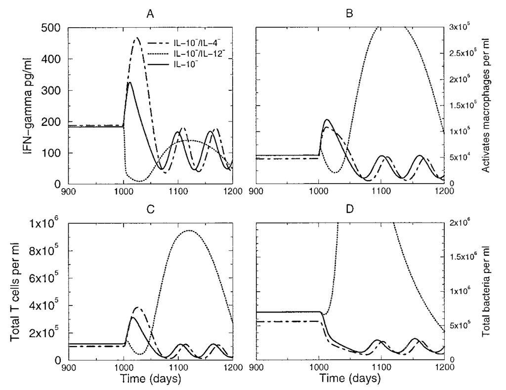

Exploring/predicting cytokine-based interventions for TB (Wigginton and Kirschner, 2001 J Imm)

## Our models

- Compartmental models (tracking total numbers of different types/compartments)
- Ordinary differential (or difference) equations

\[ \begin{aligned} \textrm{Bacteria} \qquad \dot{B} & = g B(1-\frac{B}{B_{max}}) - d_B B - kBI\\ \textrm{Immune Response} \qquad \dot{I} & = r BI - d_I I \end{aligned} \]

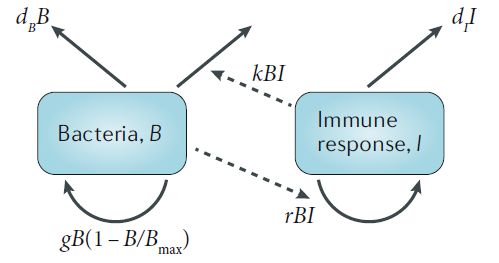

## Discussion, Q&A

- Type in Slack or Zoom Chat or just unmute yourself and ask.